# Road Crash Queensland Report

Information on crashes in Queensland for all reported road traffic crashes 2001-2010, fatal crashes to 31 December 2013, hospitalisation crashes to 30 September 2013, medical treatment and minor injury crashes to 31 December 2011.

This data has been extracted from the Queensland Road Crash Database.

This resource contains information on crashes reported to the police which resulted from the movement of at least 1 road vehicle on a road or road related area. Crashes listed in this resource have occurred on a public road and meet one of the following criteria:

- a person is killed or injured, or
- at least 1 vehicle was towed away, or
- the value of the property damage meets the appropriate criteria listed below. Property damage:
  - $2500 or more damage to property other than vehicles (after 1 December 1999)
  - $2500 or more damage to vehicle and/or other property (after 1 December 1991 and before 1 December 1999)
  - value of property damage is greater than $1000 (before December 1991).

The report can be found [Here](http://www.tmr.qld.gov.au/~/media/aboutus/corpinfo/Open%20data/crash/locations.csv)

```r
summary(Data)
```

```
##  Crash_Ref_Number              Crash_Severity    Crash_Year
##  Min.   :     1   Fatal               : 3702   Min.   :2001
##  1st Qu.: 62927   Hospitalisation     :65682   1st Qu.:2003
##  Median :125853   Medical treatment   :61209   Median :2006
##  Mean   :125853   Minor injury        :33708   Mean   :2006
##  3rd Qu.:188779   Property damage only:87404   3rd Qu.:2009
##  Max.   :251706                                Max.   :2014
##
##   Crash_Month     Crash_Day_Of_Week   Crash_Hour            Crash_Nature
##  August : 22558   Friday   :42892   Min.   : 0.00   Angle         :77838
##  July   : 22192   Monday   :33529   1st Qu.: 9.00   Hit object    :58424
##  May    : 21906   Saturday :36561   Median :13.00   Rear-end      :56486
##  March  : 21862   Sunday   :28922   Mean   :12.85   Overturned    :13992
##  October: 21463   Thursday :38108   3rd Qu.:17.00   Sideswipe     :11298
##  June   : 21361   Tuesday  :35088   Max.   :23.00   Hit pedestrian: 9346
##  (Other):120363   Wednesday:36605                   (Other)       :24321
##           Crash_Type     Crash_Longitude_GDA94 Crash_Latitude_GDA94
##  Hit pedestrian:  9346   Min.   :  0.0         Min.   :-29.15
##  Multi-Vehicle :151132   1st Qu.:151.9         1st Qu.:-27.59
##  Other         :  3984   Median :153.0         Median :-27.42
##  Single Vehicle: 87243   Mean   :151.3         Mean   :-25.68
##                          3rd Qu.:153.1         3rd Qu.:-25.29
##                          Max.   :153.6         Max.   :  0.00
##
##               Crash_Street              Crash_Street_Intersecting
##  Bruce Hwy          : 13586                          :142541
##  Gold Coast Hwy     :  3593   Warrego Hwy            :  1498
##  Pacific Hwy        :  3534   Southport - Burleigh Rd:   761
##  Warrego Hwy        :  2580   Wynnum Rd              :   643
##  Gateway Arterial Rd:  2283   West St                :   635
##  Cunningham Hwy     :  1798   New England Hwy        :   601
##  (Other)            :224331   (Other)                :105026
##             Loc_Suburb             Loc_Local_Government_Area
##  Southport       :  2840   Brisbane City        : 68013
##  Brisbane City   :  2728   Gold Coast City      : 25475
##  Surfers Paradise:  1857   Moreton Bay Region   : 16874
##  Caboolture      :  1753   Sunshine Coast Region: 15087
##  Fortitude Valley:  1692   Logan City           : 14413
##  Maroochydore    :  1537   Ipswich City         : 10227
##  (Other)         :239298   (Other)              :101616
```

[output cut: 121 more lines]

```
##  Min.   :0.00000   Min.   :0.00000   Min.   : 0.00000
##  1st Qu.:0.00000   1st Qu.:0.00000   1st Qu.: 0.00000
##  Median :0.00000   Median :0.00000   Median : 0.00000
##  Mean   :0.07938   Mean   :0.01763   Mean   : 0.03959
##  3rd Qu.:0.00000   3rd Qu.:0.00000   3rd Qu.: 0.00000
##  Max.   :4.00000   Max.   :3.00000   Max.   :11.00000
##
##  Count_Unit_Pedestrian Count_Unit_Other
##  Min.   : 0.00000      Min.   :0.00000
##  1st Qu.: 0.00000      1st Qu.:0.00000
##  Median : 0.00000      Median :0.00000
##  Mean   : 0.04134      Mean   :0.02481
##  3rd Qu.: 0.00000      3rd Qu.:0.00000
##  Max.   :11.00000      Max.   :3.00000
##
```

# Distribution of road crash in Brisbane, Queensland, Australia

The following maps shows the distribution of road crash in Brisbane, Queensland, Australia. Each green point on the map represents a road crash where the total casualty is higher than one. We can see that most points are red and therefore we can conclude that most road crash had a total casualty of one or less.

[figure not shown]

The following map shows the distribution of Road crash based on the atmospheric condition. Each green point on the map represents a road crash which occurred where the atmospheric condition was clear. We can clearly see that most road crash in Queensland occurred when the condition was clear.

This is an interesting finding as we may expect that most road crash will occur in bad atmospheric condition such as Fog, Raining or Dust. We may learn from this finding that the atmospheric condition doesn’t have a lot of affection on the statistics of road crash in Queensland.

[figure not shown]

The following plot shows the distribution of road crash in Queensland comparing the atmospheric condition and amount of casualty hospitalised. From the plot we can learn on the influence of atmospheric on the amount of casualty hospitalised.

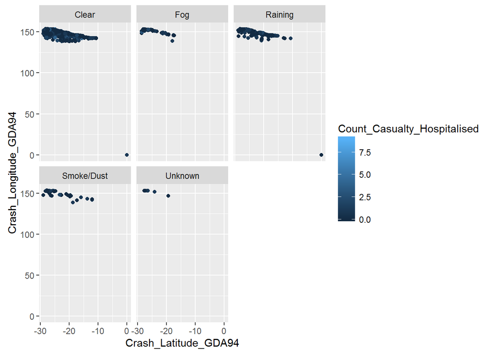

# Plots

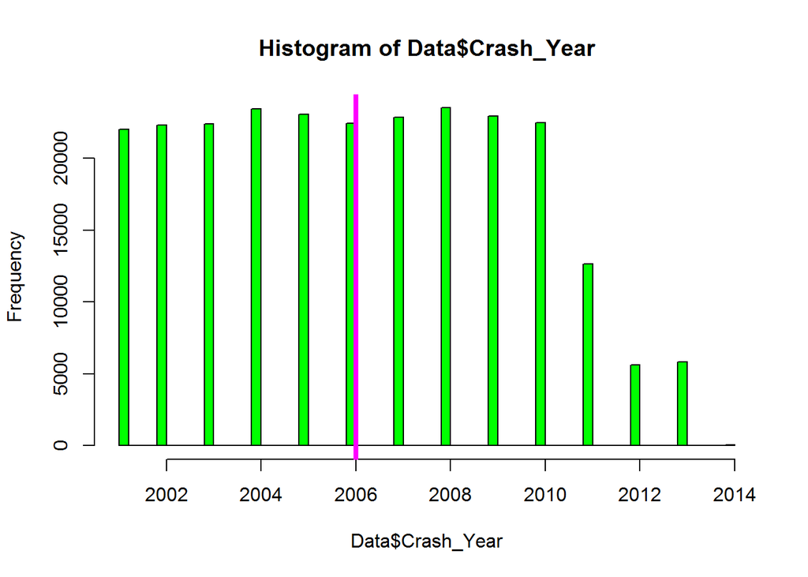

The following plot shows the frequency of road crash in Queensland in each day of week. We may see that on Sunday the least road crash occurred compare to other days. On weekends most peoples stay at home with their family and this may be the reason for this findings.

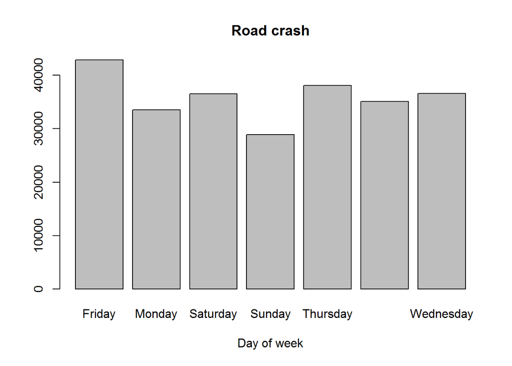

The following plot shows the count of each type of unit involved in the road crash. We may learn that in most road crash, cars were involved, in second is the Motorcycle and third is the Truck.

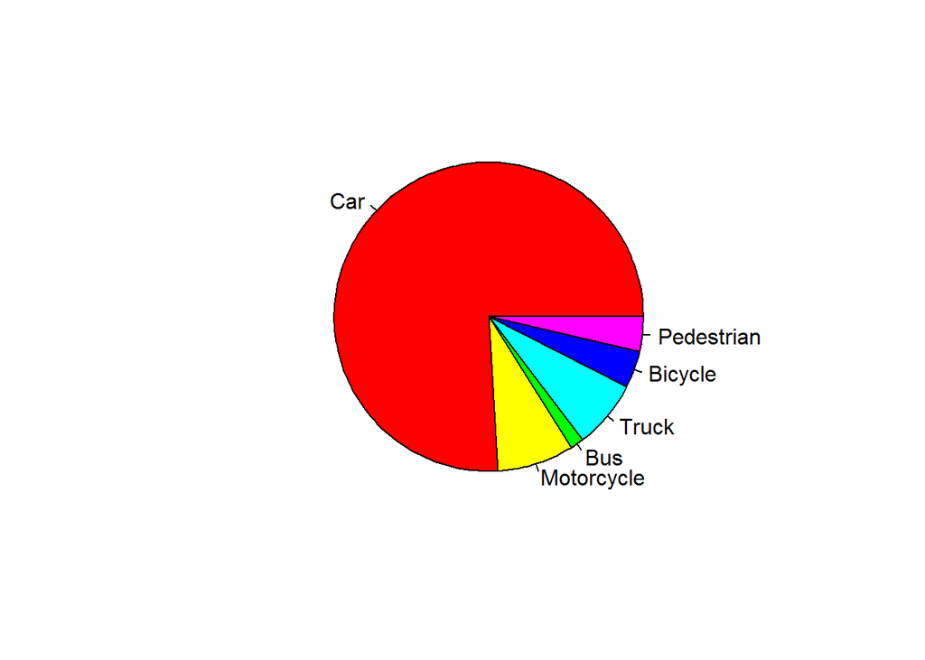

The following plot shows the number of road crash depends on the spped. We can see that most road crash occured where the speed was 60 km/h. We can conclude that most road crash occurred in lower speed.

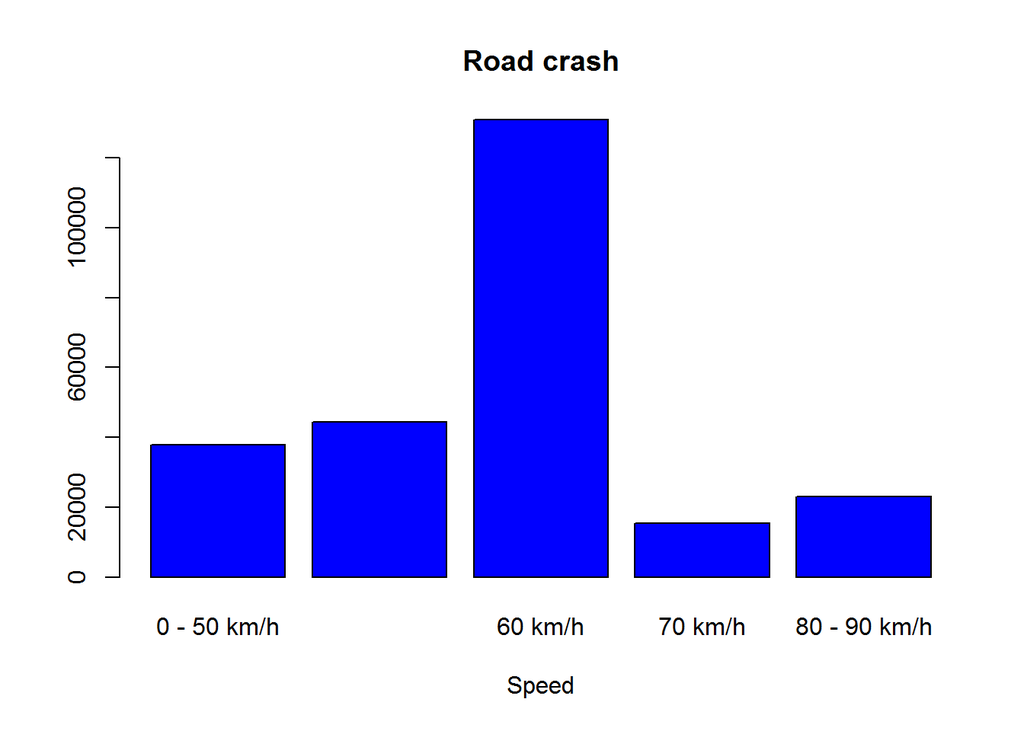

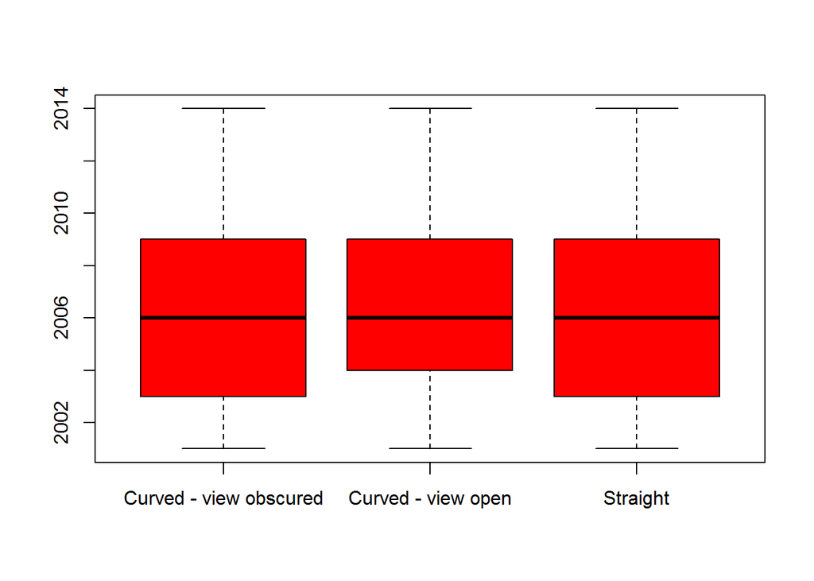

The following plot shows the crash severity of Road crash.

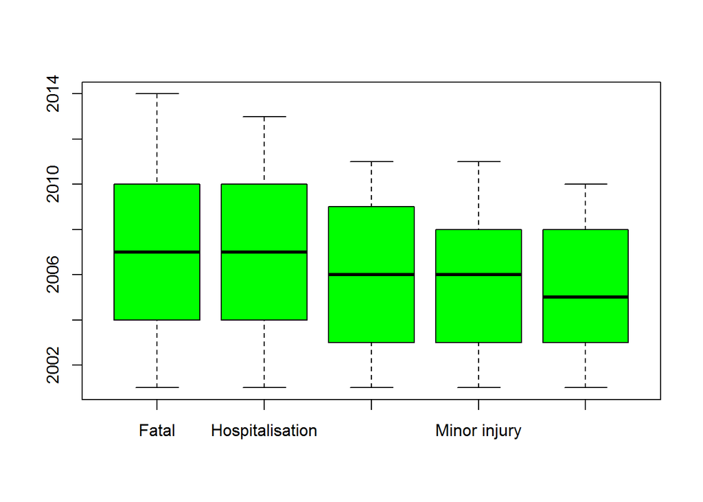